# Political (data) Science - Assignment 1

Tony Hui

The following problems use the Countries data set.

```r
POL201 = read.csv("http://www.sfu.ca/~sweldon/Countries.csv")
```

## 1)

#### Using a different variable for each type of chart, create a bar chart, a box plot, a histogram with the raw count, and a density histogram with an added density line.

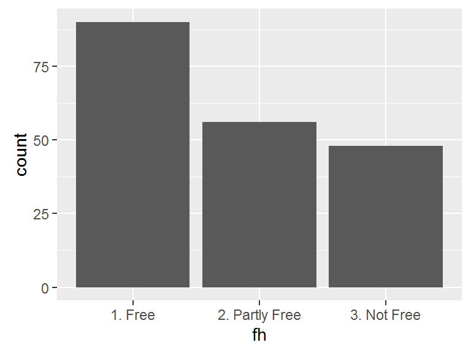

```r
library(ggplot2)
ggplot(POL201,aes(x=fh))+geom_bar()
```

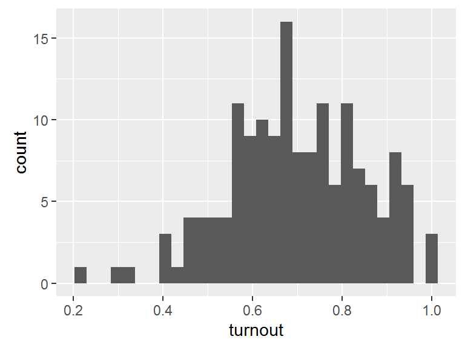

```r
ggplot(POL201,aes(x=turnout))+geom_histogram()
```

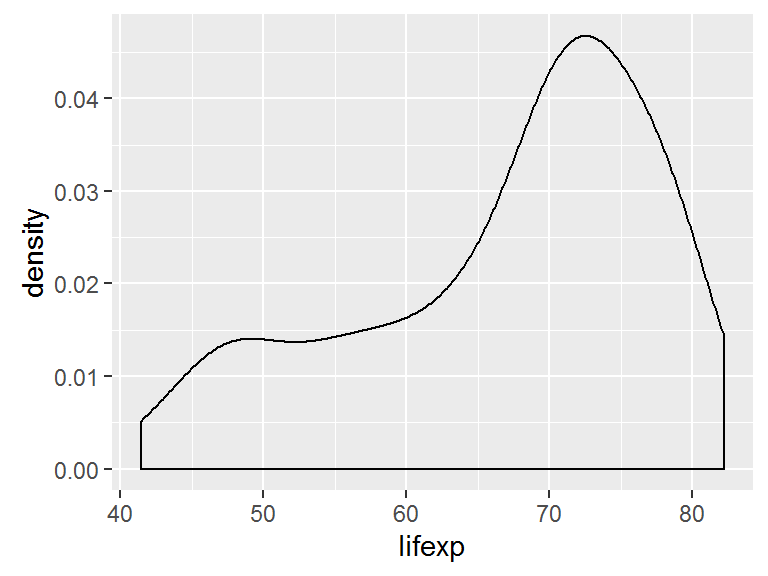

```r
ggplot(POL201,aes(x=lifexp))+geom_density()
```

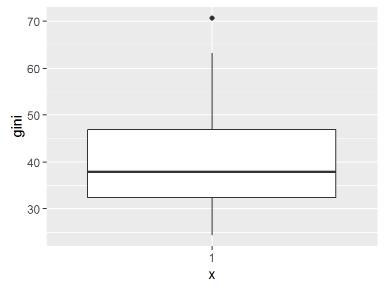

```r
ggplot(POL201,aes(x="1",y=gini))+geom_boxplot()
```

## 2)

#### Identify and calculate the value of the measure of central tendency that is most appropriate for each variable that you examined in the 4 charts above. Explain why that is the appropriate measure of central tendency. Then, calculate the standard deviation, minimum, maximum, and range for each above where appropriate.

```r
mean(POL201$gini,na.rm=TRUE)
```

```
## [1] 40.13889
```

```r
mean(POL201$turnout,na.rm=TRUE)
```

```
## [1] 0.6975881
```

```r
mean(POL201$lifexp,na.rm=TRUE)
```

```
## [1] 66.91207
```

```r
sd(POL201$turnout,na.rm=TRUE)
```

```
## [1] 0.1523052
```

```r
min(POL201$turnout,na.rm=TRUE)
```

```
## [1] 0.2157793
```

```r
max(POL201$turnout,na.rm=TRUE)
```

```
## [1] 0.9990841
```

```r
summary(POL201$turnout)
```

```
##    Min. 1st Qu.  Median    Mean 3rd Qu.    Max.    NA's
##  0.2158  0.5979  0.6902  0.6976  0.8106  0.9991      38
```

```r
sd(POL201$lifexp,na.rm=TRUE)
```

```
## [1] 10.45912
```

```r
summary(POL201$lifexp)
```

```
##    Min. 1st Qu.  Median    Mean 3rd Qu.    Max.    NA's
##   41.45   59.95   70.52   66.91   74.61   82.19       6
```

```r
sd(POL201$gini,na.rm=TRUE)
```

```
## [1] 10.35998
```

```r
summary(POL201$gini)
```

```
##    Min. 1st Qu.  Median    Mean 3rd Qu.    Max.    NA's
##   24.40   32.43   37.95   40.14   46.88   70.70      68
```

## 3)

#### Calculate at least one of the standard deviation calculations “by hand”

```r
sqrt(sum((na.omit(POL201$gini)-mean(POL201$gini,na.rm=TRUE))^2)/(length(na.omit(POL201$gini))-1))
```

```
## [1] 10.35998
```

**Z-Scores and Empirical Rule**

## 4)

#### Using the “hobbes” variable in the Countries data set, which is a composite measure of quality of life based on Hobbes claim that life is “solitary, poor, nasty, brutish and short”, find the z-scores for the following scores: 22, 61, 75, and 90. Interpret.

```r
mean(POL201$hobbes,na.rm=TRUE)
```

```
## [1] 61.26811
```

```r
sd(POL201$hobbes,na.rm=TRUE)
```

```
## [1] 20.27663
```

```r
mean.hobbes<-mean(POL201$hobbes,na.rm=TRUE)
sd.hobbes<-sd(POL201$hobbes,na.rm=TRUE)

(22-mean.hobbes)/sd.hobbes
```

```
## [1] -1.936619
```

```r
(61-mean.hobbes)/sd.hobbes
```

```
## [1] -0.01322245
```

```r
(75-mean.hobbes)/sd.hobbes
```

```
## [1] 0.6772277
```

```r
(90-mean.hobbes)/sd.hobbes
```

```
## [1] 1.416996
```

## 12)

```r
4800*0.75
```

```
## [1] 3600
```